# EDA Assignment 6

Motoki Sugino

10/27/2016

# PART A: I choose the boston marathon data set.

boston.marathon.wtimes

For your dataset.

### 1. Using R, perform a resistant smooth (3RSSH, twice) to your data. Save the smooth (the fit) and the rough (the residuals).

```r
library(LearnEDA)
head(boston.marathon.wtimes)
```

```
##   year minutes
## 1 1897     175
## 2 1898     162
## 3 1899     174
## 4 1900     159
## 5 1901     149
## 6 1902     163
```

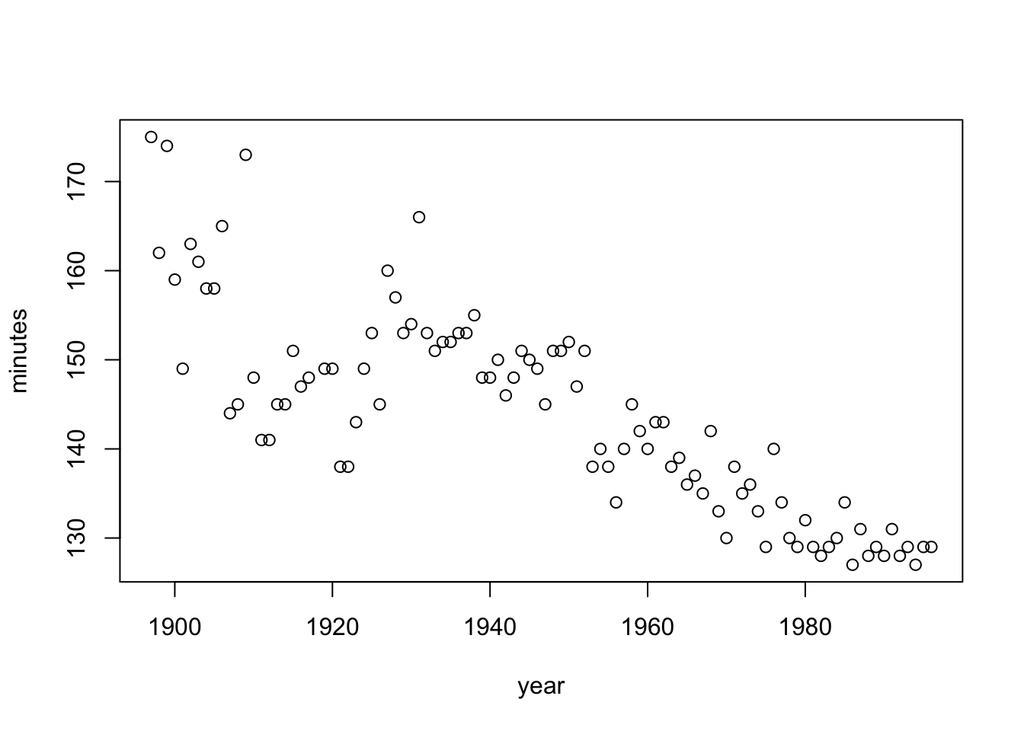

```r
with(boston.marathon.wtimes, plot(year, minutes))
```

```r
smooth.3R <- smooth(boston.marathon.wtimes$minutes, kind="3R")
smooth.3R[1:12]
```

```
##  [1] 175 174 162 159 159 161 161 158 158 158 145 145
```

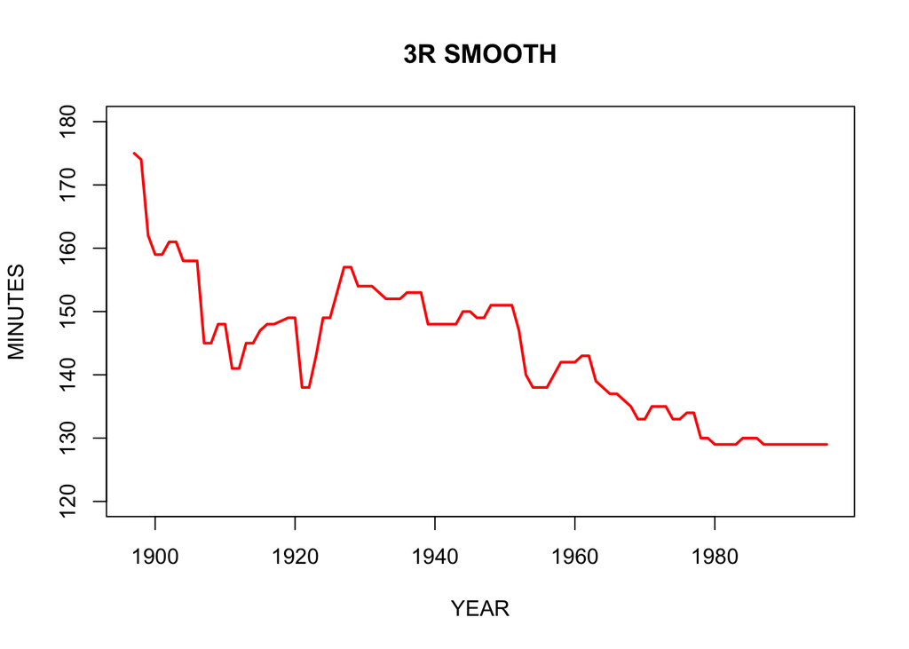

```r
with(boston.marathon.wtimes,
plot(year, smooth.3R,type="l",col="red",lwd=2, xlab="YEAR",ylab="MINUTES",
main="3R SMOOTH", ylim=c(120,180)))
```

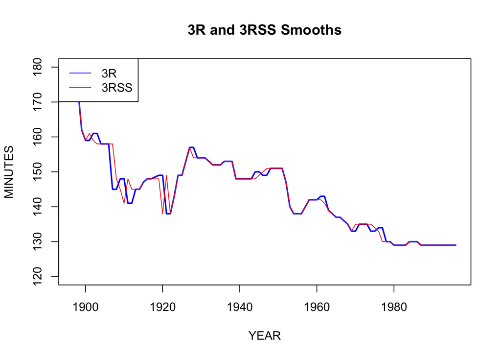

```r
#Splitting
smooth.3RSS <- smooth(boston.marathon.wtimes$minutes, kind="3RSS")
with(boston.marathon.wtimes,
plot(year, smooth.3R,type="l",col="blue",lwd=2, xlab="YEAR",ylab="MINUTES",
main="3R and 3RSS Smooths",
ylim=c(120,180)))
with(boston.marathon.wtimes,
lines(year, smooth.3RSS, col="red"))
legend("topleft", legend=c("3R", "3RSS"),
lty=1, col=c("blue", "red"))
```

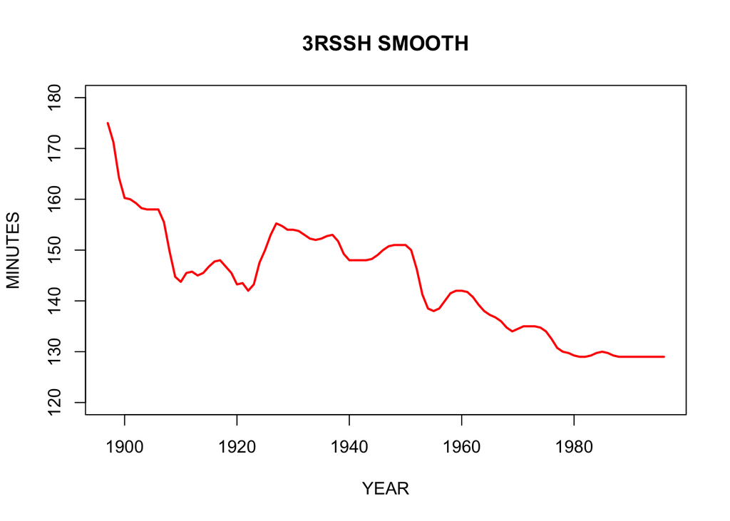

```r
#Hanning
smooth.3RSSH <- han(smooth.3RSS)
with(boston.marathon.wtimes,
plot(year, smooth.3RSSH, type="l",col="red",lwd=2,
      xlab="YEAR", ylab="MINUTES",
      main="3RSSH SMOOTH", ylim=c(120,180)))
```

```r
#The smooth and the rough (DATA = SMOOTH + ROUGH)
Rough <- with(boston.marathon.wtimes, minutes - smooth.3RSSH)
with(boston.marathon.wtimes,
head(cbind(minutes, smooth.3RSSH, Rough)))
```

```
##      minutes smooth.3RSSH  Rough
## [1,]     175       175.00   0.00
## [2,]     162       171.25  -9.25
## [3,]     174       164.25   9.75
## [4,]     159       160.25  -1.25
## [5,]     149       160.00 -11.00
## [6,]     163       159.25   3.75
```

```r
#Reroughing
options(width=60)
as.vector(Rough)
```

```
##  [1]   0.00  -9.25   9.75  -1.25 -11.00   3.75   2.75   0.00
##  [9]   0.00   7.00 -11.50  -4.75  28.25   4.25  -4.50  -4.75
## [17]   0.00  -0.50   4.25  -0.75   0.00   3.50   5.75  -5.50
## [25]  -4.00  -0.25   1.50   3.00  -8.00   4.75   2.25  -1.00
## [33]   0.00  12.25   0.00  -1.25   0.00  -0.25   0.25   0.00
## [41]   3.25  -1.25   0.00   2.00  -2.00   0.00   2.75   1.00
## [49]  -1.00  -5.75   0.00   0.00   1.00  -3.00   4.75  -3.25
## [57]   1.50   0.00  -4.50   0.00   3.50   0.00  -2.00   1.25
## [65]   2.25  -1.25   1.00  -1.25   0.25  -1.00   7.25  -1.00
## [73]  -4.50   3.00   0.00   1.00  -1.75  -5.00   7.50   3.25
## [81]   0.00  -0.75   2.75   0.00  -1.00  -0.25   0.25   4.00
## [89]  -2.75   1.75  -1.00   0.00  -1.00   2.00  -1.00   0.00
## [97]  -2.00   0.00   0.00
```

```r
smooth.3RS3R.twice <- smooth(boston.marathon.wtimes$minutes, kind="3RS3R", twiceit=TRUE)
```

We have saved the smooth (the fit) and the rough (the residuals).

### 2. Plot the smooth (using a smooth curve) and describe the general patterns that you see. Don’t assume that anything is obvious – pretend that you are explaining this to someone who doesn’t have any background in statistics.

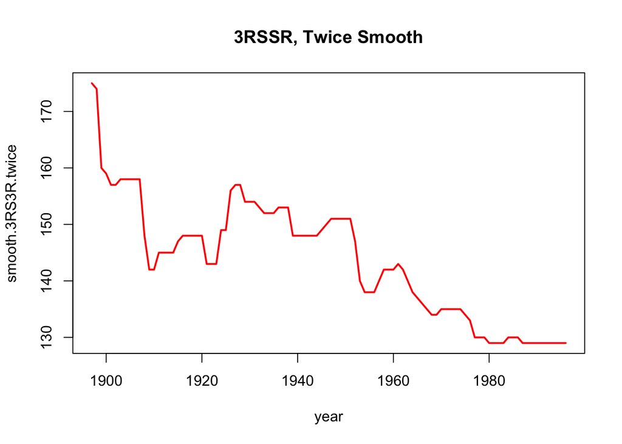

```r
with(boston.marathon.wtimes, plot(year, smooth.3RS3R.twice,
        col="red", lwd=2,  type="l",
        main="3RSSR, Twice Smooth"),ylim=c(120,180))
```

The boston.marathon’s winning time had an immediate drop between **1897** to **1900**.The winning time reached a peak about **1897**. After this early drop, the time had an immediate drop between **1904** to **1910**. After those two drops, the time showed a general increase from about year **1911** to about year **1927**. After this increase, the time showed a gereral decrease from about year 1928 to about year **1952**. As Dr Albert explained in our classnotes, there is a dip in the graph in the mid-50’s due to the shorter running distance. Therefore, the time had an immediate drop in mid-50’s. After this the time showed a increase till about year **1963**. From year **1964**, the time showed a general decrease again till about year **1975**. This suggests athletes are improving due to better equipment, better training, etc. The times since **1980** have stayed pretty constant, suggesting that maybe there is a leveling off in performance in this race.

### 3. Plot the rough (as a time series plotting individual points). Do you see any general patterns in the rough?

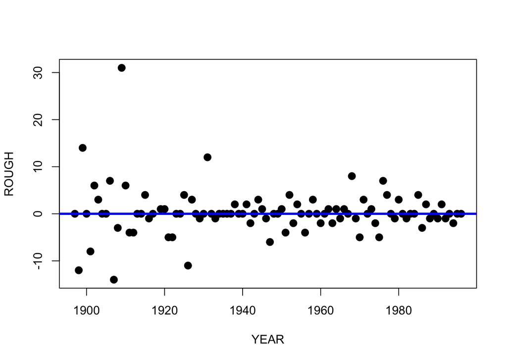

```r
FinalRough <- boston.marathon.wtimes$minutes - smooth.3RS3R.twice
plot(boston.marathon.wtimes$year, FinalRough,
pch=19, cex=1.3, xlab="YEAR", ylab="ROUGH")
abline(h=0, lwd=3, col="blue")
```

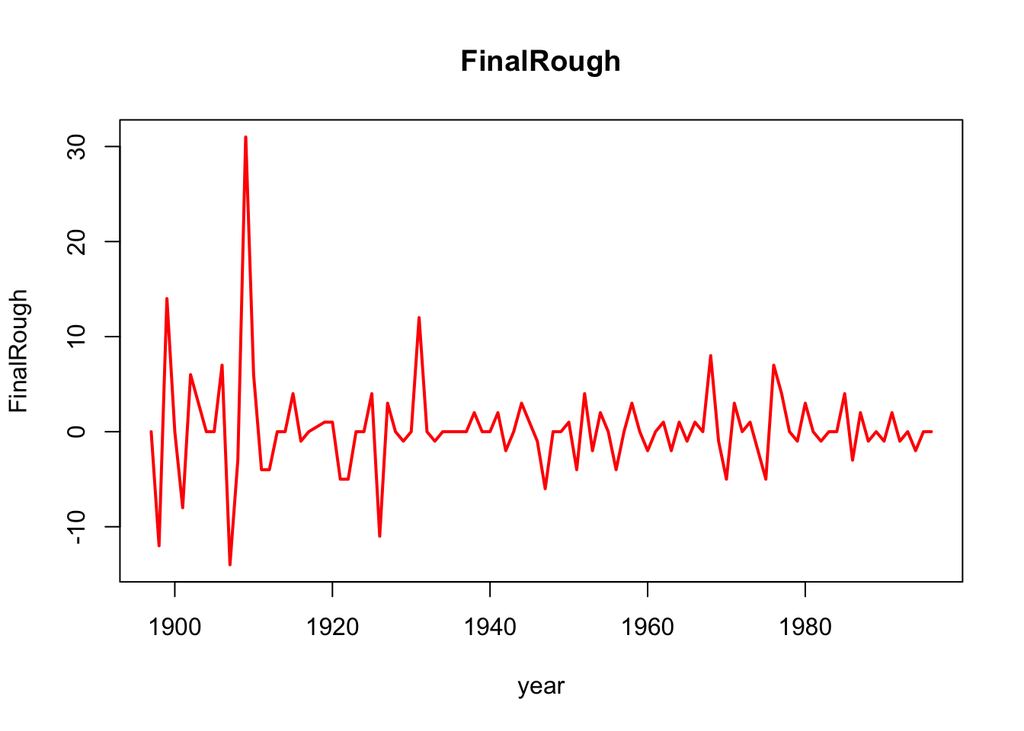

```r
with(boston.marathon.wtimes, plot(year, FinalRough,
        col="red", lwd=2,  type="l",
        main="FinalRough"))
```

### 4. Construct a stemplot and letter value display of the sizes of the rough. (The size is the absolute value of the rough.) Set up fences and look for outliers. Summarize what you have learned. (What is a typical size of a residual? Are there any unusually large residuals?)

```r
absrough <- abs(FinalRough)
aplpack::stem.leaf(absrough, depth=FALSE)
```

```
## 1 | 2: represents 1.2
##  leaf unit: 0.1
##             n: 99
##    0* | 00000000000000000000000000000000000
##    0. |
##    1* | 0000000000000000000
##    1. |
##    2* | 00000000000
##    2. |
##    3* | 00000000
##    3. |
##    4* | 000000000
##    4. |
##    5* | 0000
##    5. |
##    6* | 000
##    6. |
##    7* | 00
##    7. |
##    8* | 00
## HI: 11 12 12 14 14 31
```

```r
fivenum(absrough)
```

```
## [1]  0  0  1  4 31
```

```r
dF=4-0;dF
```

```
## [1] 4
```

```r
STEP=1.5*dF;STEP
```

```
## [1] 6
```

```r
FenceL=0-STEP;FenceL
```

```
## [1] -6
```

```r
FenceU=4+STEP;FenceU # x > FenceU should be outlier
```

```
## [1] 10
```

```r
FENCEL=0-(2*STEP);FENCEL
```

```
## [1] -12
```

```r
FENCEU=4+(2*STEP);FENCEU
```

```
## [1] 16
```

Summarizing the size of the rough. The distance between the lower and upper fourths is **4** which is the width of the middle 50% of the data. Therefore we can say that a typical size of a residual is from **0** to **4**. The upper fence is **10**, so there are **6** unusual large residuals $(11,12,12,14,14,31)$.

# PART B: Find some data collected over time (with at least 50 values) that would benefit with a smooth. Plot the smooth and describe the basic patterns that you see. Plot the rough and look for general patterns and any unusual values.

data source: https://fred.stlouisfed.org/series/JPNNGDP I am going to use this data about “Gross Domestic Product for Japan”.

```r
data <- read.csv("https://docs.google.com/spreadsheets/d/1eawH-3Xpfj1bEjlyLnXHgJ77LFUhMopUwBuaG3HTvYU/pub?output=csv")
#data <- read.csv("https://docs.google.com/spreadsheets/d/1XpEDekmOCt8v_wEIZcEnvNtK3AaCiDBNvJ6NFYSBlPQ/pub?output=csv")

head(data)
```

```
##   observation_date  JPNNGDP
## 1       1994-01-01 495059.7
## 2       1994-04-01 492499.2
## 3       1994-07-01 500136.6
## 4       1994-10-01 495307.1
## 5       1995-01-01 495171.1
## 6       1995-04-01 501284.1
```

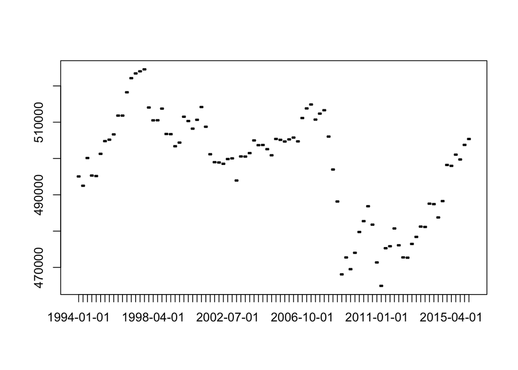

```r
with(data, plot(observation_date, JPNNGDP))
```

```r
smooth.3R <- smooth(data$JPNNGDP, kind="3R")
smooth.3R[1:12]
```

```
##  [1] 495059.7 495059.7 495307.1 495307.1 495307.1 501284.1
##  [7] 504785.0 505180.5 506644.3 511822.1 511822.2 518238.7
```

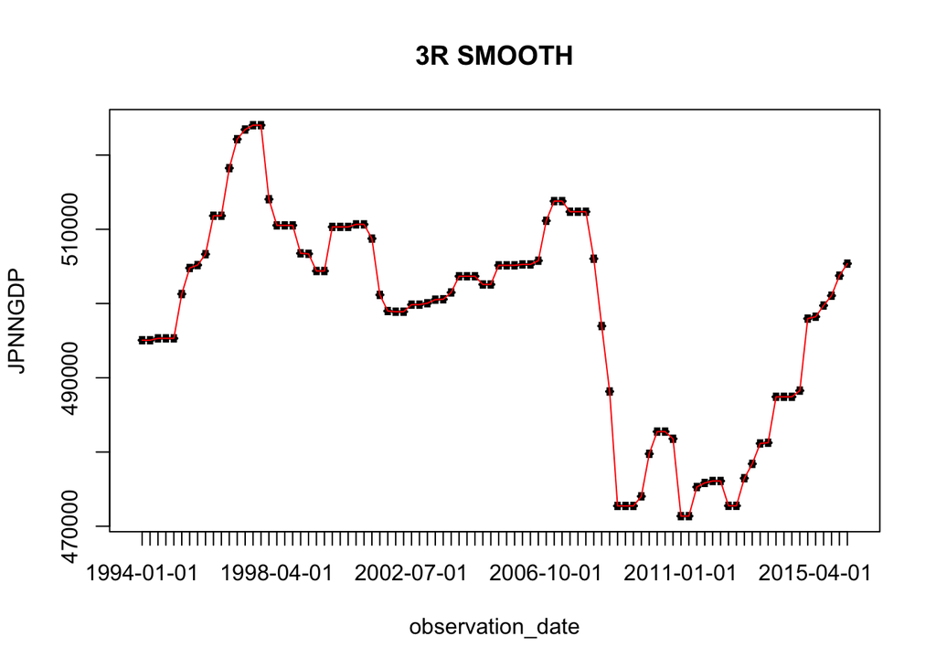

```r
with(data,
plot(observation_date, smooth.3R,type="l",col="red",lwd=2, xlab="observation_date",ylab="JPNNGDP",
main="3R SMOOTH"))
with(data,lines(observation_date, smooth.3R, col="red"))
```

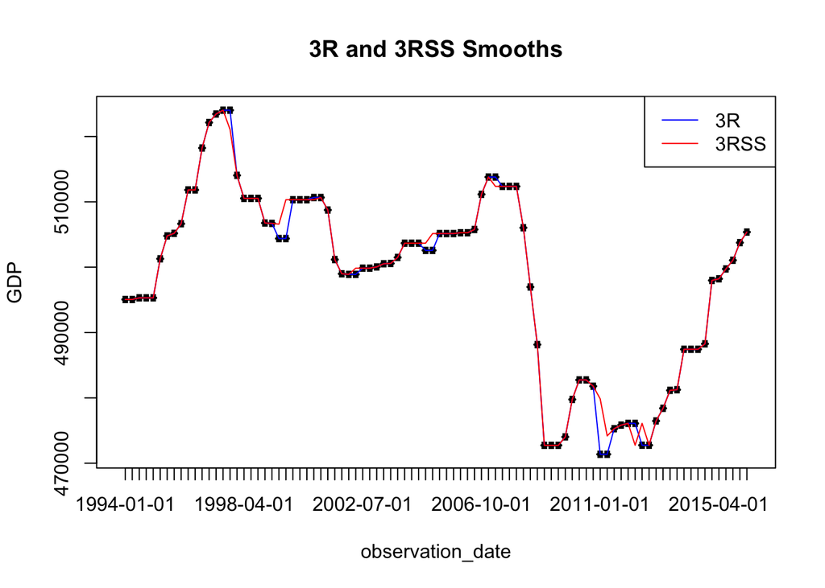

```r
smooth.3RSS <- smooth(data$JPNNGDP, kind="3RSS")
with(data,
plot(observation_date, smooth.3R,type="l",col="blue",lwd=2, xlab="observation_date",ylab="GDP",
main="3R and 3RSS Smooths"))
with(data,lines(observation_date, smooth.3R, col="blue"))
with(data,lines(observation_date, smooth.3RSS, col="red"))
legend("topright", legend=c("3R", "3RSS"),
lty=1, col=c("blue", "red"))
```

We are somewhat successful in removing these two-wide peaks and valleys.

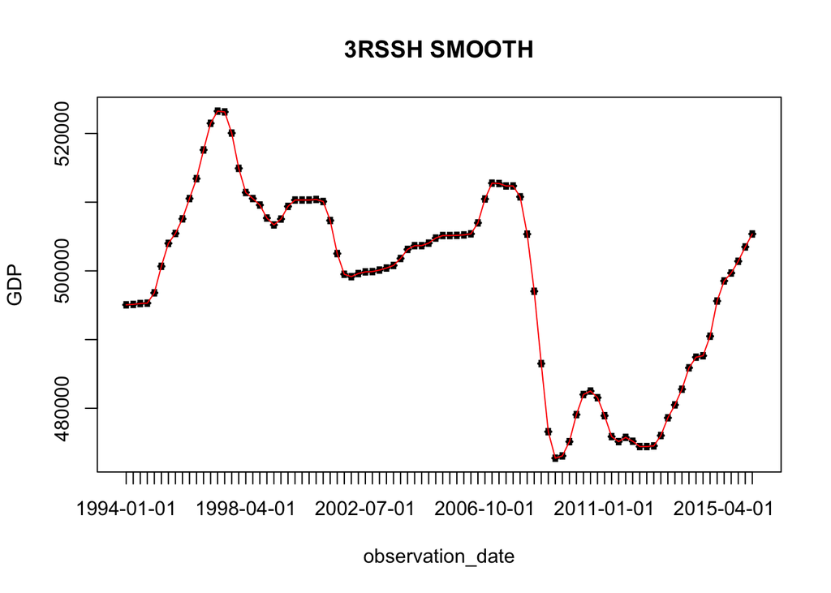

```r
#Hanning
smooth.3RSSH <- han(smooth.3RSS)
with(data,
plot(observation_date, smooth.3RSSH, type="l",col="red",lwd=2,
      xlab="observation_date", ylab="GDP",
      main="3RSSH SMOOTH"))
with(data,lines(observation_date, smooth.3RSSH, col="red"))
```

This hanning operation is good in smoothing the bumpy monotone sequences that we saw in the 3RSS smooth.

```r
#The smooth and the rough (DATA = SMOOTH + ROUGH)
Rough <- with(data, JPNNGDP - smooth.3RSSH)
with(data,
head(cbind(JPNNGDP, smooth.3RSSH, Rough)))
```

```
##       JPNNGDP smooth.3RSSH     Rough
## [1,] 495059.7     495059.7     0.000
## [2,] 492499.2     495121.5 -2622.350
## [3,] 500136.6     495245.2  4891.350
## [4,] 495307.1     495307.1     0.000
## [5,] 495171.1     496801.3 -1630.250
## [6,] 501284.1     500665.1   619.025
```

```r
#Reroughing
options(width=60)
as.vector(Rough)
```

```
##  [1]      0.000  -2622.350   4891.350      0.000  -1630.250
##  [6]    619.025    776.350   -267.075   -928.500   1294.525
## [11]  -1604.200    630.075    648.975    178.375    881.200
## [16]   4502.400   -879.500   -900.700      0.000   4156.800
## [21]   -927.600     14.600  -4171.400  -5004.400   1185.900
## [26]      0.000  -2095.400    256.500   4082.775   1417.400
## [31]  -1350.450   -523.050   -259.375  -1072.900      0.000
## [36]    141.750  -6179.725    154.100   -262.850   -316.400
## [41]   1850.525      0.000     46.500  -1472.375  -3883.525
## [46]    243.900      0.000   -495.200     30.700    377.175
## [51]  -2267.650    682.850   1018.900   2156.825  -1648.700
## [56]      0.000   2513.250    685.000    -62.675   1650.000
## [61]  -8508.675      0.000  -3548.600  -1110.575    685.750
## [66]    747.125   4340.975    241.175  -7547.725 -10958.475
## [71]    137.925     72.975   5532.200   1669.100  -1669.100
## [76]  -1842.600    443.875   -201.750    758.975  -1619.475
## [81]   1667.525      0.000  -3885.575  -2216.475   2612.900
## [86]   -564.600   1372.350  -1669.175    268.725      0.000
```

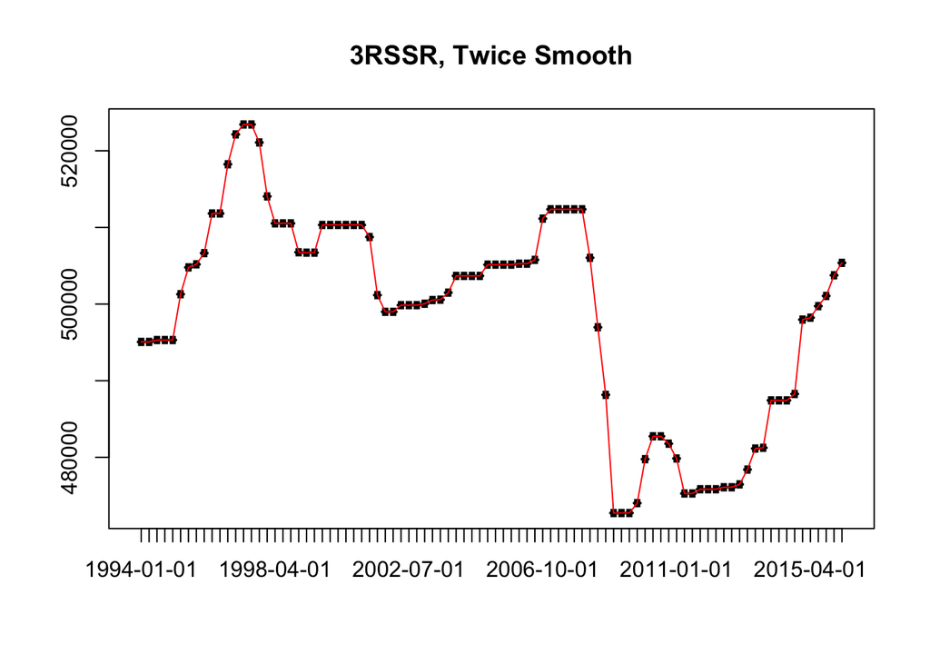

```r
smooth.3RS3R.twice <- smooth(data$JPNNGDP, kind="3RS3R", twiceit=TRUE)

with(data, plot(observation_date, smooth.3RS3R.twice,
        col="red", lwd=2,  type="l",
        main="3RSSR, Twice Smooth"))
with(data,lines(observation_date, smooth.3RS3R.twice, col="red"))
```

Japanese GDP had an immediate increase between year **1994** to **1997** and GDP in Japan reached a peak about **1997**. After this early increase, the Japanese GDP had an immediate drop between year **1997** to **1998**. The year between **1998** and **2000** have stayed pretty constant,suggesting that maybe Japanese economy was stable at that time . There is an immediate drop between year **2001** to year **2003**. Then,the year between **2003** and **2004** have a general increase. GDP for Japan had an immediate drop between year **2008** to **2009**. This makes sense because bankruptcy of lehman brothers damaged world’s economy and effects japanese economy as well. There is small bump between year **2009** and year **2011** and there is an immediate increase between year **2011** to year **2016**. Current Japanese GDP is getting closer to the GDP value in **2008**.

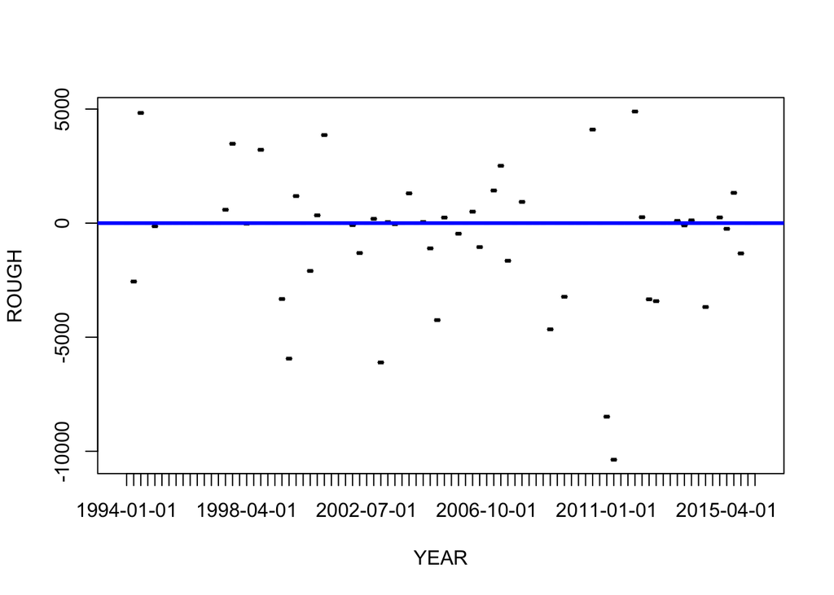

```r
FinalRough <- data$JPNNGDP - smooth.3RS3R.twice
plot(data$observation_date, FinalRough,
pch=19, cex=1.3, xlab="YEAR", ylab="ROUGH")
abline(h=0, lwd=3, col="blue")
```

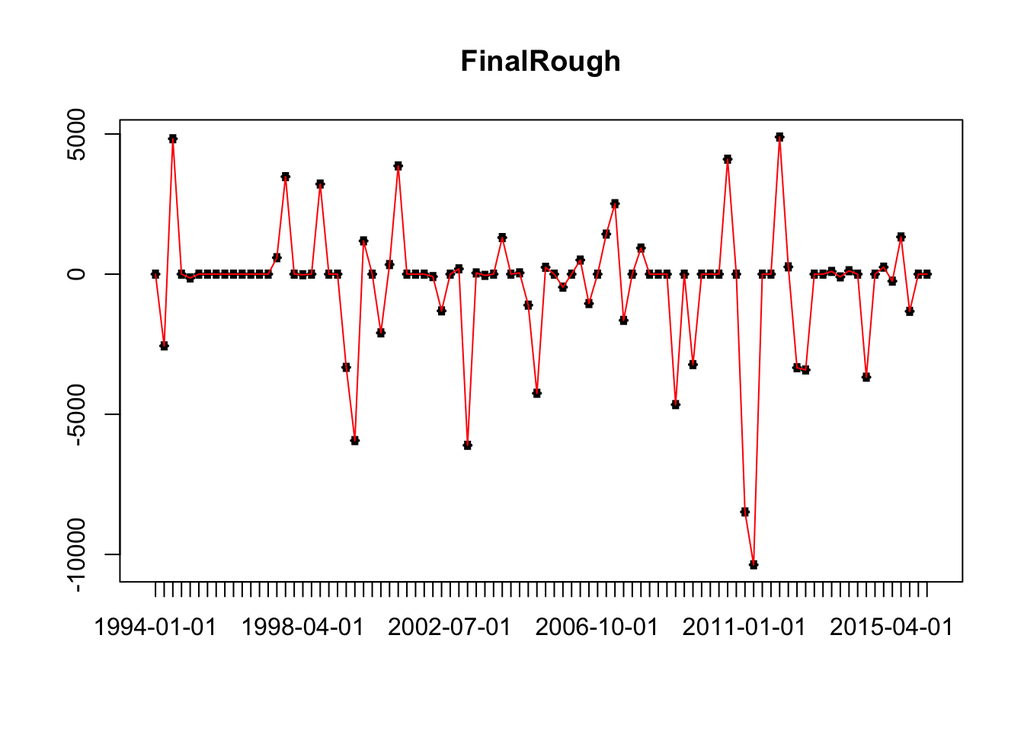

```r
with(data, plot(observation_date, FinalRough,
        col="red", lwd=2,  type="l",
        main="FinalRough"))
with(data,lines(observation_date, FinalRough, col="red"))
```

There are two huge negative deviation in **2011** which are **-8483.4** and **-10368.0**. Except those two deviation,overall the rough is pretty constant betwenn 5000 to **-5000**. while there are a number of years (6 to be exact) where the rough is around **+5000**, there are a number of years (9 to be exact) where the rough is around **-5000**. This might indicates that neggative impact on Japanese economy is very influential. This is very interesting that the rough in **2008** where the collapse of lehman brothers occurred is not unusual.

```r
absrough <- abs(FinalRough)
aplpack::stem.leaf(absrough, depth=FALSE)
```

```
## 1 | 2: represents 1200
##  leaf unit: 100
##             n: 90
##    0* | 0000000000000000000000000000000000000000000000000111
##     t | 22223
##     f | 455
##     s |
##    0. | 9
##    1* | 011
##     t | 3333
##     f | 4
##     s | 6
##    1. |
##    2* | 0
##     t |
##     f | 55
##     s |
##    2. |
##    3* |
##     t | 2233
##     f | 44
##     s | 6
##    3. | 8
##    4* | 0
## HI: 4250.39999999985 4654.69999999995 4829.5 4892.5 5937.79999999987 6105.79999999999 8483.39999999985 10368
```

```r
fivenum(1)
```

[output not shown]

```
## [1] 1 1 1 1 1
```

```r
dF=1326.8-0;dF
```

```
## [1] 1326.8
```

```r
STEP=1.5*dF;STEP
```

```
## [1] 1990.2
```

```r
FenceL=0-STEP;FenceL
```

```
## [1] -1990.2
```

```r
FenceU=1326.8+STEP;FenceU # x > FenceU should be outlier
```

```
## [1] 3317
```

```r
FENCEL=0-(2*STEP);FENCEL
```

```
## [1] -3980.4
```

```r
FENCEU=1326.8+(2*STEP);FENCEU
```

```
## [1] 5307.2
```

Summarizing the size of the rough. The distance between the lower and upper fourths is **1326.8** which is the width of the middle 50% of the data. Therefore we can say that a typical size of a residual is from **0** to **1326.8**. The upper FENCE is **5307.2** so there are **4** unusual large residuals $(5937.8, 6105.8, 8483.4, 10368.0)$.